# homework3

Brian

February 18, 2018

### Question 3.2

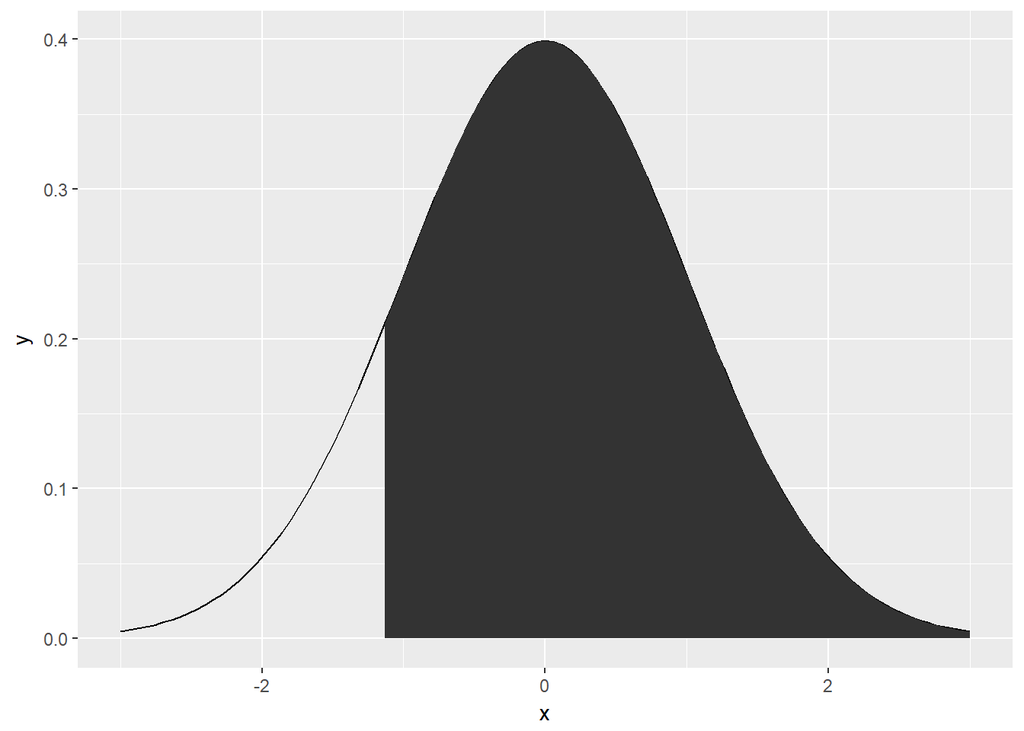

```r
normal.plot <- ggplot(data=data.frame(x=c(-3,3)), aes(x)) + stat_function(fun=dnorm, args=list(mean=0, sd=1))
normal.plot + stat_function(fun=dnorm, xlim=c(-1.13, 3), geom='area')
```

```r
pnorm(q=-1.13, mean=0, sd=1, lower.tail=FALSE)
```

```
## [1] 0.8707619
```

- 1. $\approx$ 87%

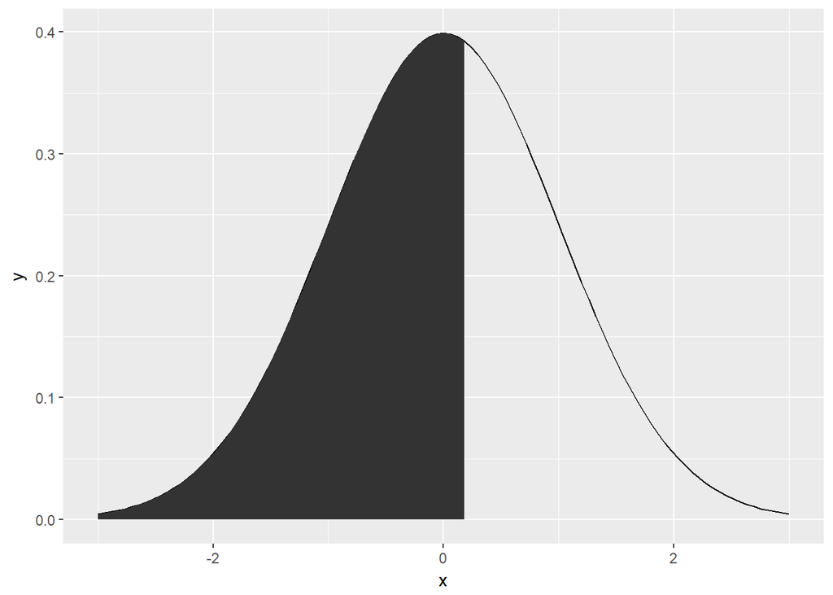

```r
normal.plot + stat_function(fun=dnorm, xlim=c(-3, .18), geom='area')
```

```r
pnorm(q=.18, mean=0, sd=1)
```

```
## [1] 0.5714237
```

- 2. $\approx$ 57%

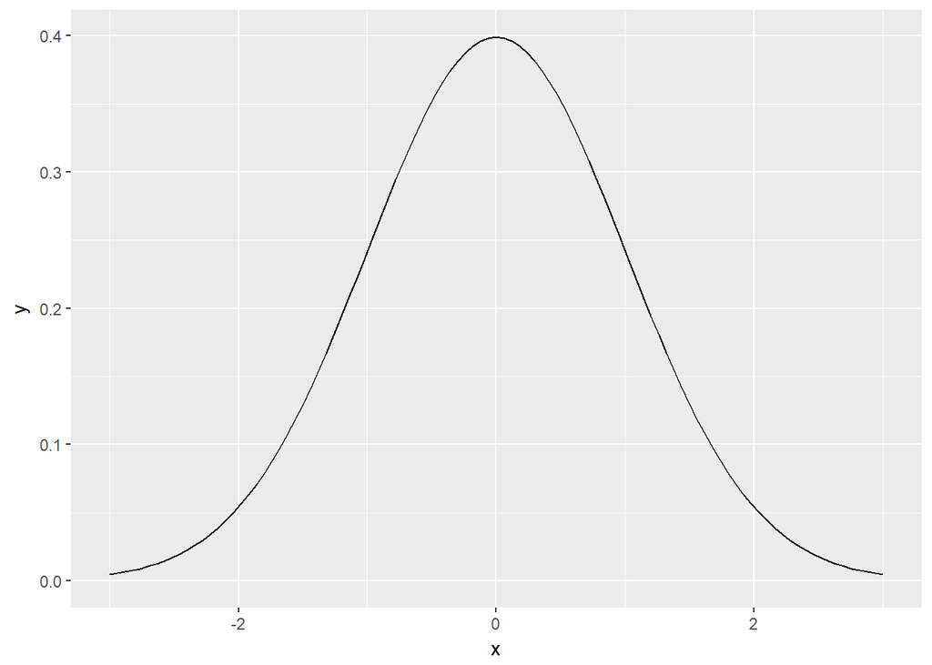

```r
normal.plot + stat_function(fun=dnorm, xlim=c(3, 3), geom='area')
```

```r
pnorm(q=8, mean=0, sd=1, lower.tail=FALSE)
```

```
## [1] 6.220961e-16
```

- 3. $\approx$ 0%

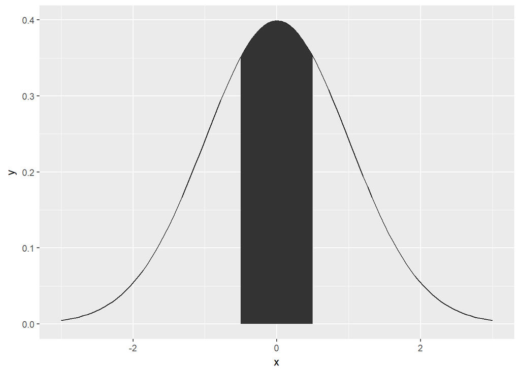

```r
normal.plot + stat_function(fun=dnorm, xlim=c(-.5, .5), geom='area')
```

```r
pnorm(q=.5, mean=0, sd=1) - pnorm(q=-.5, mean=0, sd=1)
```

```
## [1] 0.3829249
```

- 4. $\approx$ 38%

### Question 3.4

- 1. Men’s: $N(4313, 583)$ Women’s: $N(5261, 807)$
- 2. Leo’s Z-score: $\frac{4948-4313}{583} \approx 1.09$ Mary’s Z-score: $\frac{5513-5261}{807} \approx 0.31$

Leo’s finishing time z-score is 1.08 meaning that his time is about 1 standard deviation above the mean finishing times in his group. Mary’s is 0.31 meaning that she is approximately 0.31 standard deviation above her groups finishing time.

- 3. Mary performed better than Leo. While both times are bove average, her’s has a smaller z score indiciating that she performed better than a larger proportion of her group than Leo did of his group.

```r
pnorm(q=4948, mean=4313, sd=583, lower.tail=FALSE)
```

```
## [1] 0.1380342
```

- 4. $\approx$ 14%

```r
pnorm(q=5513, mean=5261, sd=807, lower.tail=FALSE)
```

```
## [1] 0.3774186
```

- 5. $\approx$ 37%
- 6. b would remain the same. A z-score is a z-score. The formula does not change based on the distribution. c through e however would change. The linking of z score to a certain proportion of the population is contingent on the data being roughly normally distributed. Without this information there is no consistant way to use the z-score to determine the porportion of racers Leo or Mary performed better than.

### Question 3.18

- 1. Yes, the data adhears to the 68-95-99.7 rule

```r
female.heights <- c(54, 55, 56, 56, 57, 58, 58, 59, 60, 60, 60, 61, 61, 62, 62, 63, 63, 63, 64, 65, 65, 67, 67, 69, 73)
length(female.heights[female.heights > 56.94 & female.heights < 66.1]) / 25
```

```
## [1] 0.68
```

Z-score for 68% is -1 to 1 corresponding to a range of (56.94, 66.1)

```r
length(female.heights[female.heights > 52.36 & female.heights < 70.69]) / 25 #96%
```

```
## [1] 0.96
```

```r
length(female.heights[female.heights > 47.78 & female.heights < 75.26]) / 25 #68%
```

```
## [1] 1
```

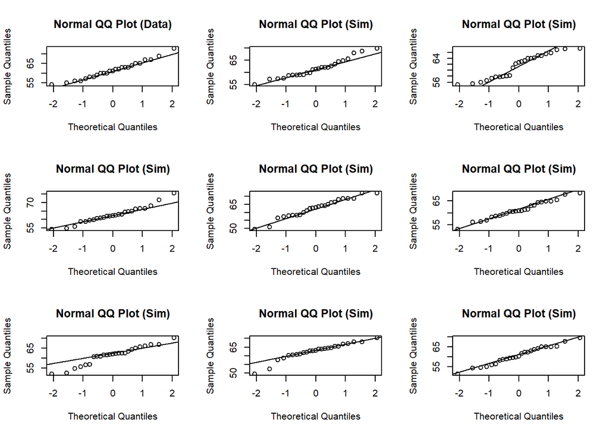

```r
qqnormsim(female.heights)
```

- 2. The actual data looks very similar to the simulated data. Most of the values fit nicely on the normal probability plot line with a few upper and lower outliers. It is safe to say that this data is roughly normal.

### Question 3.22

```r
dgeom(9, .02)
```

```
## [1] 0.01667496
```

- 1. 9 failures followed by a success at 2% has $\approx$ 1.6% chance of occuring

```r
pgeom(100, .02)
```

```
## [1] 0.8700328
```

### Question 3.38

```r
dbinom(2, 3, .51)
```

```
## [1] 0.382347
```

- 1. $\approx$ 38%
- 2. MMF, MFM, FMM 0.51 $\times$ 0.51 $\times$ 0.49 + 0.51 $\times$ 0.49 $\times$ 0.51 + 0.49 $\times$ 0.51 $\times$ 0.51 $\approx$ 38%
- 3. There is no need to perform seperate calculations for each scenario, account for disjoing probabilities, and sum those values. This would be tedious, repetitive work.

### Question 3.42

```r
dnbinom(7, 3, .15)
```

```
## [1] 0.03895012
```

- 1. $\approx$ 3.9%
- 2. 15%. The trials are independent
- 3. The probability calculated in part b is not equivalent to that in part a. We cannot ignore the fact that her 10th serve will, in some scenarios, have a 0% chance of being her 3rd successful serve.